# Project 3 Data Science NanoDegree

Fang Lu

11/4/2015

### 1. Injestion and Familiarization of the Data

This is an exploration of the tidy data set **wineQualityReds.csv** provided by Udacity Data Analyst Nanodegree for Project 3. This data set was chosen for the brevity of the observations in consideration for execution time of certain plots. Guiding question: “Which Variables affect Red Wine Quality?”

*Initial Explorations:*

```r
names(wqr)
```

```
##  [1] "X"                    "fixed.acidity"        "volatile.acidity"
##  [4] "citric.acid"          "residual.sugar"       "chlorides"
##  [7] "free.sulfur.dioxide"  "total.sulfur.dioxide" "density"
## [10] "pH"                   "sulphates"            "alcohol"
## [13] "quality"
```

```r
str(wqr)
```

```
## 'data.frame':    1599 obs. of  13 variables:
##  $ X                   : int  1 2 3 4 5 6 7 8 9 10 ...
##  $ fixed.acidity       : num  7.4 7.8 7.8 11.2 7.4 7.4 7.9 7.3 7.8 7.5 ...
##  $ volatile.acidity    : num  0.7 0.88 0.76 0.28 0.7 0.66 0.6 0.65 0.58 0.5 ...
##  $ citric.acid         : num  0 0 0.04 0.56 0 0 0.06 0 0.02 0.36 ...
##  $ residual.sugar      : num  1.9 2.6 2.3 1.9 1.9 1.8 1.6 1.2 2 6.1 ...
##  $ chlorides           : num  0.076 0.098 0.092 0.075 0.076 0.075 0.069 0.065 0.073 0.071 ...
##  $ free.sulfur.dioxide : num  11 25 15 17 11 13 15 15 9 17 ...
##  $ total.sulfur.dioxide: num  34 67 54 60 34 40 59 21 18 102 ...
##  $ density             : num  0.998 0.997 0.997 0.998 0.998 ...
##  $ pH                  : num  3.51 3.2 3.26 3.16 3.51 3.51 3.3 3.39 3.36 3.35 ...
##  $ sulphates           : num  0.56 0.68 0.65 0.58 0.56 0.56 0.46 0.47 0.57 0.8 ...
##  $ alcohol             : num  9.4 9.8 9.8 9.8 9.4 9.4 9.4 10 9.5 10.5 ...
##  $ quality             : int  5 5 5 6 5 5 5 7 7 5 ...
```

```r
summary(wqr)
```

```
##        X          fixed.acidity   volatile.acidity  citric.acid
##  Min.   :   1.0   Min.   : 4.60   Min.   :0.1200   Min.   :0.000
##  1st Qu.: 400.5   1st Qu.: 7.10   1st Qu.:0.3900   1st Qu.:0.090
##  Median : 800.0   Median : 7.90   Median :0.5200   Median :0.260
##  Mean   : 800.0   Mean   : 8.32   Mean   :0.5278   Mean   :0.271
##  3rd Qu.:1199.5   3rd Qu.: 9.20   3rd Qu.:0.6400   3rd Qu.:0.420
##  Max.   :1599.0   Max.   :15.90   Max.   :1.5800   Max.   :1.000
##  residual.sugar     chlorides       free.sulfur.dioxide
##  Min.   : 0.900   Min.   :0.01200   Min.   : 1.00
##  1st Qu.: 1.900   1st Qu.:0.07000   1st Qu.: 7.00
##  Median : 2.200   Median :0.07900   Median :14.00
##  Mean   : 2.539   Mean   :0.08747   Mean   :15.87
##  3rd Qu.: 2.600   3rd Qu.:0.09000   3rd Qu.:21.00
##  Max.   :15.500   Max.   :0.61100   Max.   :72.00
##  total.sulfur.dioxide    density             pH          sulphates
##  Min.   :  6.00       Min.   :0.9901   Min.   :2.740   Min.   :0.3300
##  1st Qu.: 22.00       1st Qu.:0.9956   1st Qu.:3.210   1st Qu.:0.5500
##  Median : 38.00       Median :0.9968   Median :3.310   Median :0.6200
##  Mean   : 46.47       Mean   :0.9967   Mean   :3.311   Mean   :0.6581
##  3rd Qu.: 62.00       3rd Qu.:0.9978   3rd Qu.:3.400   3rd Qu.:0.7300
##  Max.   :289.00       Max.   :1.0037   Max.   :4.010   Max.   :2.0000
##     alcohol         quality
##  Min.   : 8.40   Min.   :3.000
##  1st Qu.: 9.50   1st Qu.:5.000
##  Median :10.20   Median :6.000
##  Mean   :10.42   Mean   :5.636
##  3rd Qu.:11.10   3rd Qu.:6.000
##  Max.   :14.90   Max.   :8.000
```

Some parameter names may be a bit long to plot on ggpairs, perhaps a renaming of the parameters will be needed later. There are 1599 observations of red wine in the data-set (rather small considering other data-sets). Alcohol content of red wines range from 8.40% to 14.90% with most around 10%. The quality rating of reds in this data set are mostly between 5 and 6 with median at 6. pH of reds are stable around 3-4,

### 2. Free Exploration and Transformation

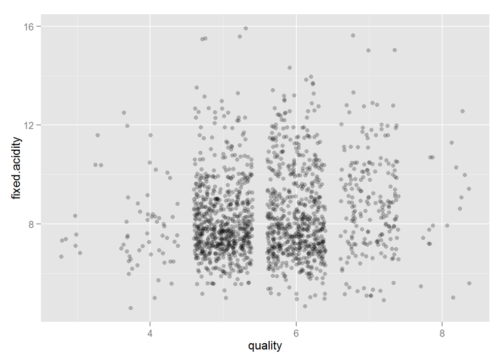

```r
#Added jitter and some transparency to the basic plot
ggplot(aes(x = quality, y = fixed.acidity), data = wqr) +
  geom_point(alpha = 1/4, position = 'jitter')
```

It seems that fixed acidity has little to do with the quality of red wines, and that there are more quality 5 to 7 wines than there qualities of other types, this is also noted in the readme *wineQualityInfo.txt*. Perhaps it would be better to combine the bottom two levels and the top two levels.

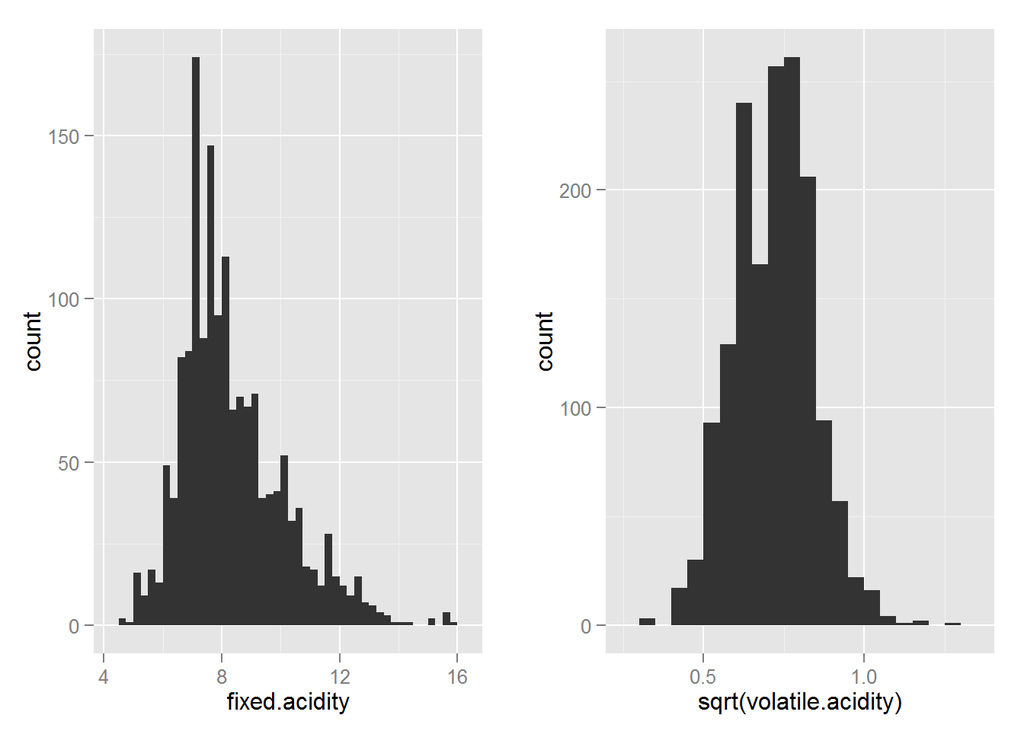

```r
#Early Histogram Generation to get an idea of the distribution of parameters
h1 <- ggplot(aes(x = fixed.acidity), data = wqr) +
  geom_histogram(binwidth = .25)
h2 <- ggplot(aes(x = sqrt(volatile.acidity)), data = wqr) +
  geom_histogram(binwidth = .05)
grid.arrange(h1, h2, ncol = 2)
```

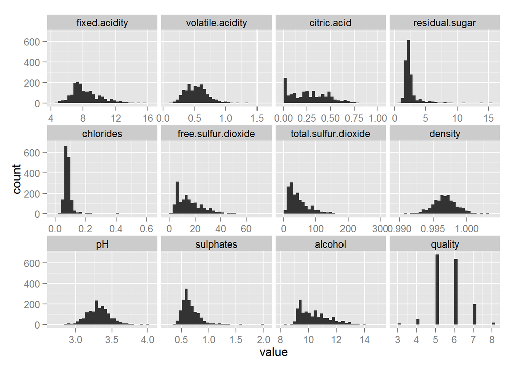

```r
#Using Reshape2 to melt the data together to generate a histogram gridplot for
#an overview
meltwqr <- melt(wqr, id = c('X'))
gridHist <- ggplot(aes(x=value), data=meltwqr) +
  geom_histogram() +
  facet_wrap(~variable, ncol = 4, scale='free_x', shrink=TRUE)
gridHist
```

The histogram grid took some research to create (at first attempted a function that did not work as intended). This provided a good overview of the distribution of the different chemical attributes, *residual.sugar* and *chlorides* and perhaps *sulphates* could possibly use a closer look at the X-scaling for they seem to be more long-tailed. An extra note, density seems to be rather normally distributed.

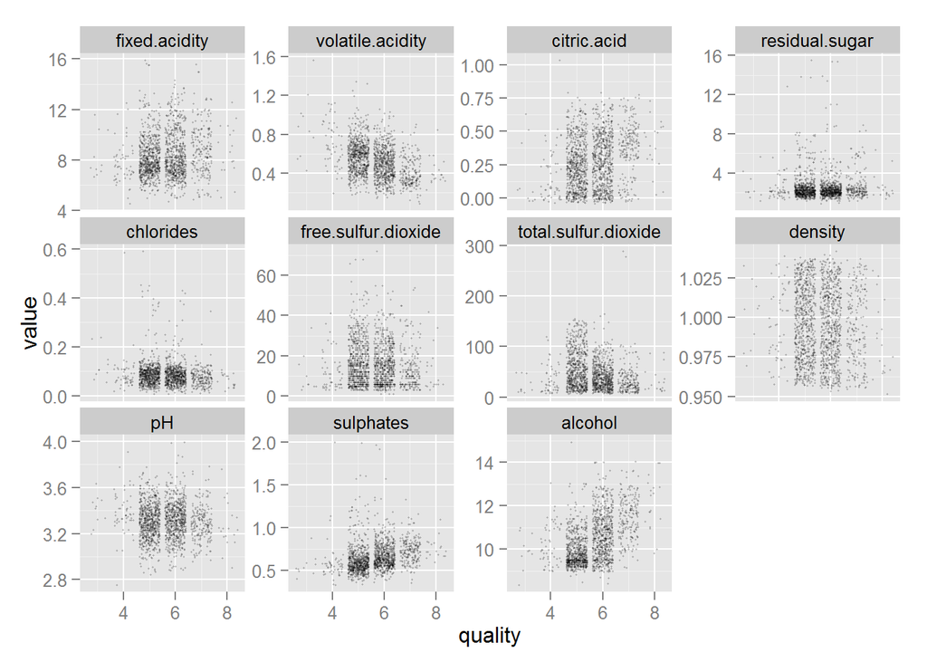

```r
#created a second transformation of the data using melt from reshape2 library to
#get a scatter plot of all the input variables vs quality
scattwqr <- melt(wqr, id = c('X','quality'))
gridScatt <- ggplot(aes(x=quality, y = value), data = scattwqr) +
  geom_point(alpha = 1/4, position= "jitter", size=0.5) +
  facet_wrap(~variable, ncol=4, scale='free_y')
gridScatt
```

From the scatter plots, *sulphates*, *alcohol* content seems to have a bit of correlation with quality where higher alcohol content seems to indicate higher quality, but the variance is still pretty high.

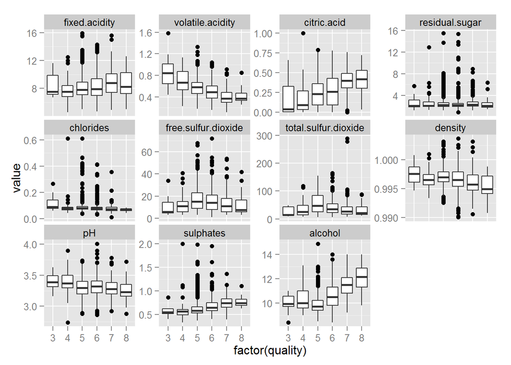

```r
#Boxplots for graphical statistical summary of all the input variables vs
#quality
gridBox <- ggplot(aes(x=factor(quality), y = value), data = scattwqr) +
  geom_boxplot() + facet_wrap(~variable, ncol=4, scale='free_y')
gridBox
```

The boxplots seem to reveal some interesting trends where the other plots showed relatively little. A re-scaling of the Y-axis for *residual.sugar*, *chlorides*, and *sulphates* might reveal a better view of the boxplots.

```r
#with(wqr, cor.test(quality, citric.acid, method = 'pearson'))
#with(wqr, cor.test(quality, volatile.acidity, method = 'pearson'))
#with(wqr, cor.test(quality, fixed.acidity, method = 'pearson'))
#with(wqr, cor.test(quality, alcohol, method = 'pearson'))
#with(wqr, cor.test(quality, sulphates, method = 'pearson'))
#with(wqr, cor.test(quality, chlorides, method = 'pearson'))
#with(wqr, cor.test(density, alcohol, method = 'pearson'))
#with(wqr, cor.test(density, quality, method = 'pearson'))
with(wqr, cor.test(quality, fixed.acidity, method = 'pearson'))
```

```
##
##  Pearson's product-moment correlation
##
## data:  quality and fixed.acidity
## t = 4.996, df = 1597, p-value = 6.496e-07
## alternative hypothesis: true correlation is not equal to 0
## 95 percent confidence interval:
##  0.07548957 0.17202667
## sample estimates:
##       cor
## 0.1240516
```

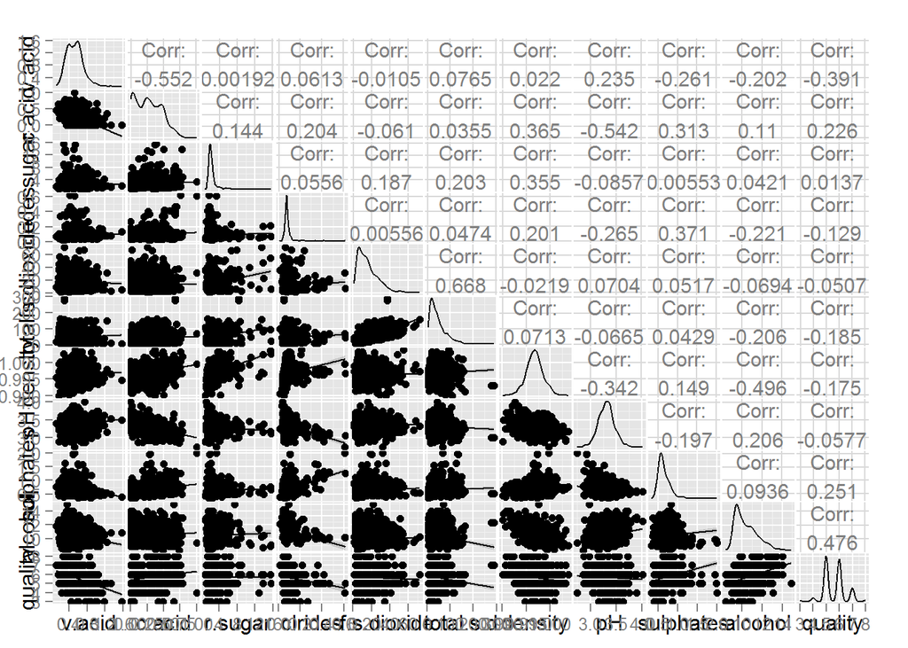

```r
#No need to sample since our dataset is relatively small
#create a new dataframe with condensed naming for ggpairs
newnames = c('X', "f.acid",'v.acid','c.acid','r.sugar', 'clrides',
             'f.s.dioxide','total.s.d', 'density','pH','sulphates',
             'alcohol','quality')
wqrRen <- wqr
colnames(wqrRen) <- newnames
#ggpairs(wqrRen[3:13], params = c(shape = I('.'), outlier.shape = I('.')))

#run ggpairs for 10 of the variables, see newnames for the column names.
ggpairs(wqrRen[3:13], upper = list(params = c(size = 4)),
        lower = list(continuous = "smooth"))
```

```r
#Some sanity checks

with(wqr, cor.test(fixed.acidity, pH))
```

```
##
##  Pearson's product-moment correlation
##
## data:  fixed.acidity and pH
## t = -37.3659, df = 1597, p-value < 2.2e-16
## alternative hypothesis: true correlation is not equal to 0
## 95 percent confidence interval:
##  -0.7082857 -0.6559174
## sample estimates:
##        cor
## -0.6829782
```

A sanity check with *fixed acidity* vs *pH* shows that as expected there is a reasonably high correlation: -.68. Looking at the correlation coefficients, it seems that *alcholol*, *volatile acidity*, *sulphates*, and *acid acid* have the four highest correlation with *quality*. *pH*, *residual sugar* and *free sulfur dioxide* are seemingly uncorrelated with *quality*.

**Citric Acid**

```r
summary(wqr$citric.acid)
```

```
##    Min. 1st Qu.  Median    Mean 3rd Qu.    Max.
##   0.000   0.090   0.260   0.271   0.420   1.000
```

```
## stat_bin: binwidth defaulted to range/30. Use 'binwidth = x' to adjust this.
```

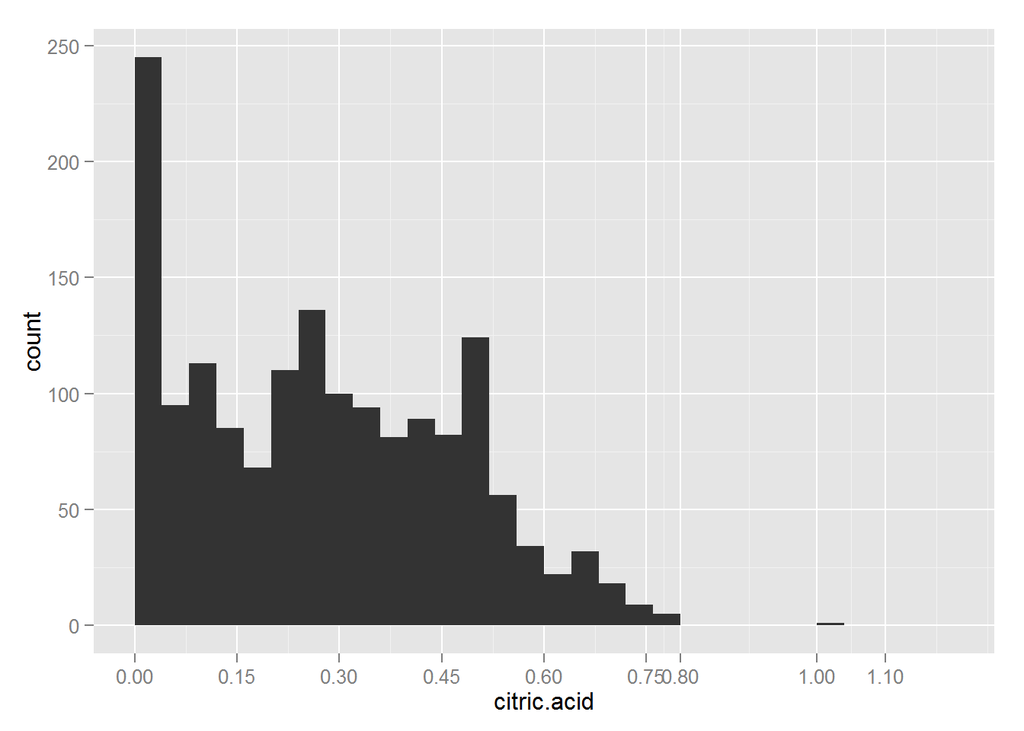

```r
ggplot(aes(x = citric.acid), data = wqr) + geom_histogram() +
  scale_x_continuous(limits = c(0, 1.2),
                     breaks = c(0, .15, .3, .45, .6, .75, .8, 1, 1.1))
```

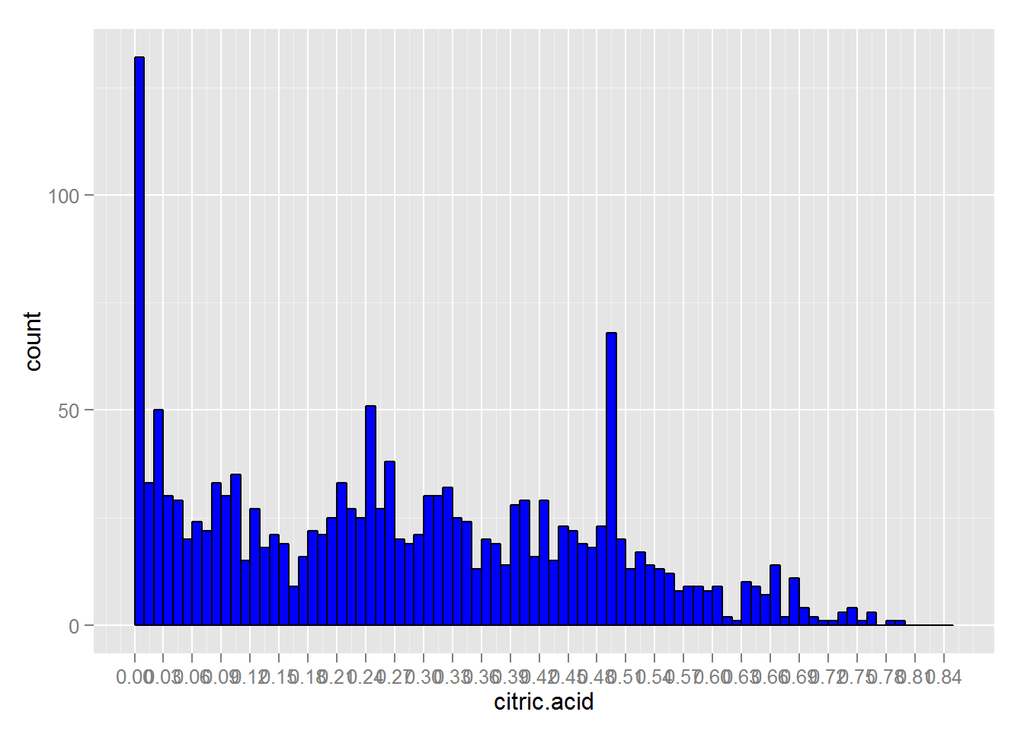

```r
ggplot(aes(x = citric.acid), data = wqr) +
  geom_histogram(binwidth = .01,color = 'black', fill='blue') +
  scale_x_continuous(limits = c(0, .85), breaks = seq(0,.85,.03))
```

```r
wqr$cAcid.cut <- cut(wqr$citric.acid, breaks = c(.001,.15,.30,.50,1.2))
levels(wqr$cAcid.cut)
```

```
## [1] "(0.001,0.15]" "(0.15,0.3]"   "(0.3,0.5]"    "(0.5,1.2]"
```

```r
with(wqr, cor.test(quality, as.numeric(cAcid.cut), method = 'pearson'))
```

```
##
##  Pearson's product-moment correlation
##
## data:  quality and as.numeric(cAcid.cut)
## t = 9.2631, df = 1465, p-value < 2.2e-16
## alternative hypothesis: true correlation is not equal to 0
## 95 percent confidence interval:
##  0.1862839 0.2829939
## sample estimates:
##      cor
## 0.235221
```

Created the categorical variable *cAcid cut* from citric.acid by looking at the histogram (which is relatively evenly distributed) and then maximizing the correlation. I feel that more categorical variables could help simply and visualize how each attribute may be attributing to the *quality* factor. Also, correlation increases with the new categorical variable.

**Free and Total Sulfur Dioxide**

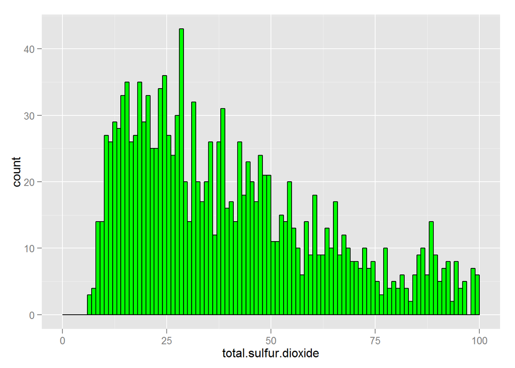

```r
#The readme gave hints as to the cutoffs to free total sulfur dioxide to a
#categorical variable. Perhaps cut total sulfur dioxide as well might affect
#taste since it's correlated with free sulfure dioxide
ggplot(aes(x=total.sulfur.dioxide), data = wqr) +
  geom_histogram(binwidth = 1, color = 'black',fill='green') +
  xlim(0,100)
```

```r
#Chose the cutoff levels experimentally maximizing the correlation. Started with
#~50 and 3 levels moved 4 and tweaked the 50 cutoff to 59
wqr$total.sulf.dioxide.cut <- cut(wqr$total.sulfur.dioxide,
                                  breaks = c(0,59,109,300))

levels(wqr$total.sulf.dioxide.cut)
```

```
## [1] "(0,59]"    "(59,109]"  "(109,300]"
```

```r
with(wqr, cor.test(quality, as.numeric(total.sulf.dioxide.cut),
                   method = 'pearson'))
```

```
##
##  Pearson's product-moment correlation
##
## data:  quality and as.numeric(total.sulf.dioxide.cut)
## t = -8.6666, df = 1597, p-value < 2.2e-16
## alternative hypothesis: true correlation is not equal to 0
## 95 percent confidence interval:
##  -0.2582798 -0.1646315
## sample estimates:
##        cor
## -0.2119421
```

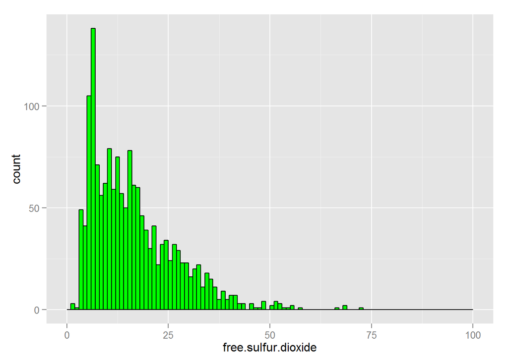

```r
ggplot(aes(x=free.sulfur.dioxide), data = wqr) +
  geom_histogram(binwidth = 1, color = 'black',fill='green')+xlim(0,100)
```

```r
summary(subset(wqr, wqr$free.sulfur.dioxide>=50))
```

```
##        X          fixed.acidity    volatile.acidity  citric.acid
##  Min.   :  15.0   Min.   : 5.900   Min.   :0.1900   Min.   :0.0000
##  1st Qu.: 447.0   1st Qu.: 6.600   1st Qu.:0.3775   1st Qu.:0.0450
##  Median :1057.5   Median : 7.350   Median :0.6000   Median :0.2000
##  Mean   : 901.2   Mean   : 7.883   Mean   :0.5178   Mean   :0.2072
##  3rd Qu.:1296.8   3rd Qu.: 8.900   3rd Qu.:0.6300   3rd Qu.:0.3300
##  Max.   :1559.0   Max.   :11.800   Max.   :0.7350   Max.   :0.4900
##  residual.sugar     chlorides       free.sulfur.dioxide
##  Min.   : 1.700   Min.   :0.04500   Min.   :50.0
##  1st Qu.: 2.575   1st Qu.:0.07575   1st Qu.:51.0
##  Median : 4.300   Median :0.10550   Median :52.5
##  Mean   : 5.950   Mean   :0.12322   Mean   :56.0
##  3rd Qu.: 7.600   3rd Qu.:0.16950   3rd Qu.:56.5
##  Max.   :15.400   Max.   :0.23500   Max.   :72.0
##  total.sulfur.dioxide    density             pH          sulphates
##  Min.   : 63.0        Min.   :0.9934   Min.   :3.160   Min.   :0.4400
##  1st Qu.: 77.5        1st Qu.:0.9957   1st Qu.:3.200   1st Qu.:0.5300
##  Median : 96.5        Median :0.9979   Median :3.290   Median :0.7200
##  Mean   :103.7        Mean   :0.9979   Mean   :3.312   Mean   :0.6750
##  3rd Qu.:124.0        3rd Qu.:0.9992   3rd Qu.:3.438   3rd Qu.:0.8075
##  Max.   :160.0        Max.   :1.0037   Max.   :3.590   Max.   :0.9300
##     alcohol          quality             cAcid.cut total.sulf.dioxide.cut
##  Min.   : 9.000   Min.   :5.000   (0.001,0.15]:3   (0,59]   : 0
##  1st Qu.: 9.425   1st Qu.:5.000   (0.15,0.3]  :5   (59,109] :10
##  Median : 9.500   Median :5.000   (0.3,0.5]   :7   (109,300]: 8
##  Mean   : 9.978   Mean   :5.556   (0.5,1.2]   :0
##  3rd Qu.:10.275   3rd Qu.:6.000   NA's        :3
##  Max.   :12.900   Max.   :7.000
```

```r
wqr$free.cut <- cut(wqr$free.sulfur.dioxide, breaks = c(0,10,20,30,40,50,100))

with(wqr, cor.test(quality, as.numeric(free.cut), method = 'pearson'))
```

```
##
##  Pearson's product-moment correlation
##
## data:  quality and as.numeric(free.cut)
## t = -1.9126, df = 1597, p-value = 0.05598
## alternative hypothesis: true correlation is not equal to 0
## 95 percent confidence interval:
##  -0.096599360  0.001219402
## sample estimates:
##         cor
## -0.04780459
```

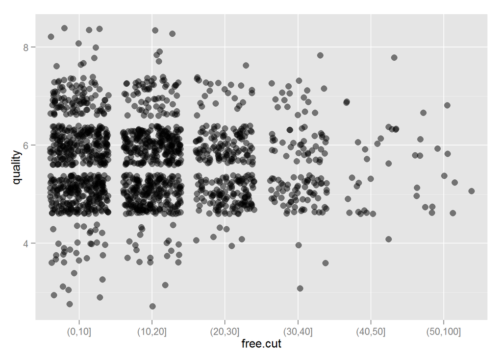

```r
ggplot(aes(y=quality, x=free.cut),data=wqr) +
  geom_point(size=3,position='jitter',alpha=.5)
```

**Chlorides and Density**

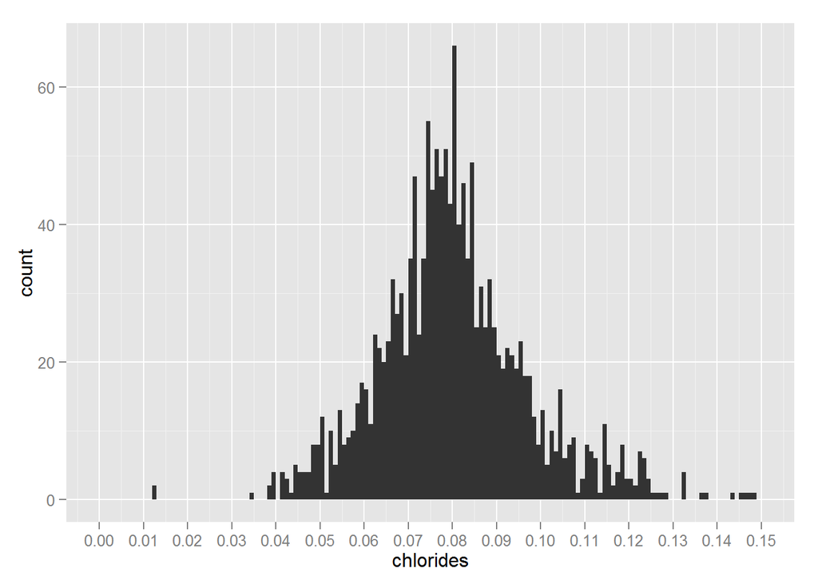

```r
#Chlorides and Density a closer look
ggplot(aes(x=chlorides), data = wqr)+geom_histogram(binwidth = .001)+
  scale_x_continuous(limits = c(0, .15), breaks = seq(0,.15,0.01))
```

```r
wqr$chloride.cut<- cut(wqr$chlorides, breaks =
                         c(0, quantile(wqr$chlorides, 0.25),
                           quantile(wqr$chlorides, 0.5),
                           quantile(wqr$chlorides, 0.75), .7))

levels(wqr$chloride.cut)
```

```
## [1] "(0,0.07]"     "(0.07,0.079]" "(0.079,0.09]" "(0.09,0.7]"
```

```r
with(wqr, cor.test(quality, as.numeric(chloride.cut), method = 'pearson'))
```

```
##
##  Pearson's product-moment correlation
##
## data:  quality and as.numeric(chloride.cut)
## t = -7.0399, df = 1597, p-value = 2.846e-12
## alternative hypothesis: true correlation is not equal to 0
## 95 percent confidence interval:
##  -0.2206370 -0.1255389
## sample estimates:
##        cor
## -0.1734924
```

Both Density and chlorides have very normal distributions, and have reasonable correlations with quality. After resizing the x-axis, it seems that chlorides is a very normally distributed variable. Turning chloride into a categorical variable increased it’s correlation with quality from -0.12 to -0.17.

```r
#Density very normally distributed

wqr$density.cut<- cut(wqr$density, breaks = c(0, quantile(wqr$density, 0.33),
                                              quantile(wqr$density, 0.66),1.1))
levels(wqr$density.cut)
```

```
## [1] "(0,0.996]"     "(0.996,0.997]" "(0.997,1.1]"
```

```r
with(wqr, cor.test(quality, as.numeric(density.cut), method = 'pearson'))
```

```
##
##  Pearson's product-moment correlation
##
## data:  quality and as.numeric(density.cut)
## t = -7.0216, df = 1597, p-value = 3.232e-12
## alternative hypothesis: true correlation is not equal to 0
## 95 percent confidence interval:
##  -0.2202076 -0.1250947
## sample estimates:
##        cor
## -0.1730546
```

**Rabbit Hole Idea**

```r
wqr$dcut<- cut(wqr$density,
  breaks = c(0, quantile(wqr$density, 1/12),quantile(wqr$density, 2/12),
             quantile(wqr$density, 3/12),quantile(wqr$density, 4/12),
             quantile(wqr$density, 5/12),quantile(wqr$density, 6/12),
             quantile(wqr$density, 7/12),quantile(wqr$density, 8/12),
             quantile(wqr$density, 9/12),quantile(wqr$density, 10/12),
             quantile(wqr$density, 11/12),quantile(wqr$density, 12/12)))

levels(wqr$dcut)
```

```
##  [1] "(0,0.9942]"      "(0.9942,0.9951]" "(0.9951,0.9956]"
##  [4] "(0.9956,0.996]"  "(0.996,0.9964]"  "(0.9964,0.9968]"
##  [7] "(0.9968,0.9971]" "(0.9971,0.9974]" "(0.9974,0.9978]"
## [10] "(0.9978,0.9984]" "(0.9984,0.9994]" "(0.9994,1.004]"
```

```r
levels(wqr$dcut)<-c("1","2","3","4","5","6","6","5","4","3","2","1")

with(wqr, cor.test(quality, as.numeric(dcut), method = 'pearson'))
```

```
##
##  Pearson's product-moment correlation
##
## data:  quality and as.numeric(dcut)
## t = -6.8116, df = 1597, p-value = 1.363e-11
## alternative hypothesis: true correlation is not equal to 0
## 95 percent confidence interval:
##  -0.2152739 -0.1199932
## sample estimates:
##       cor
## -0.168026
```

There was a thought that evenly distributed variables like density and pH despite the low correlation might have more to say. The idea is simple, “too high density, or pH or too low density or pH” will mostly likely produce ‘bad’ quality wines. As wine makers try to create ‘good’ wines they should all tend toward the middle of the distribution. By cutting the data into 12 equal parts and then combining the ends together towards the center, the new categorical variable might reveal better correlation with the *‘quality’* factor. A slight drop in correlation was found :(.

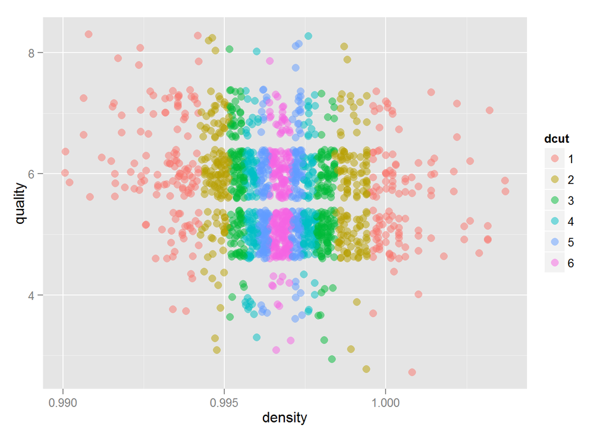

```r
ggplot(aes(x=density, y=quality, color=dcut), data=wqr) +
  geom_point(alpha = 1/2, position="jitter", size=3)
```

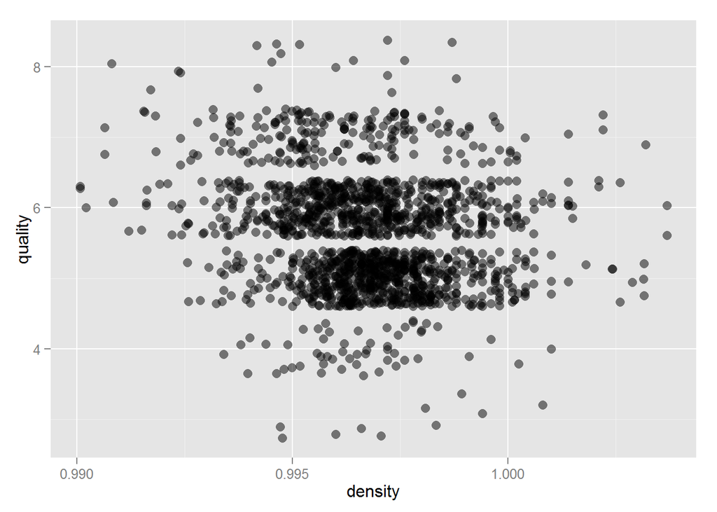

```r
ggplot(aes(x=density, y=quality), data=wqr) +
  geom_point(alpha = 1/2, position="jitter", size=3)
```

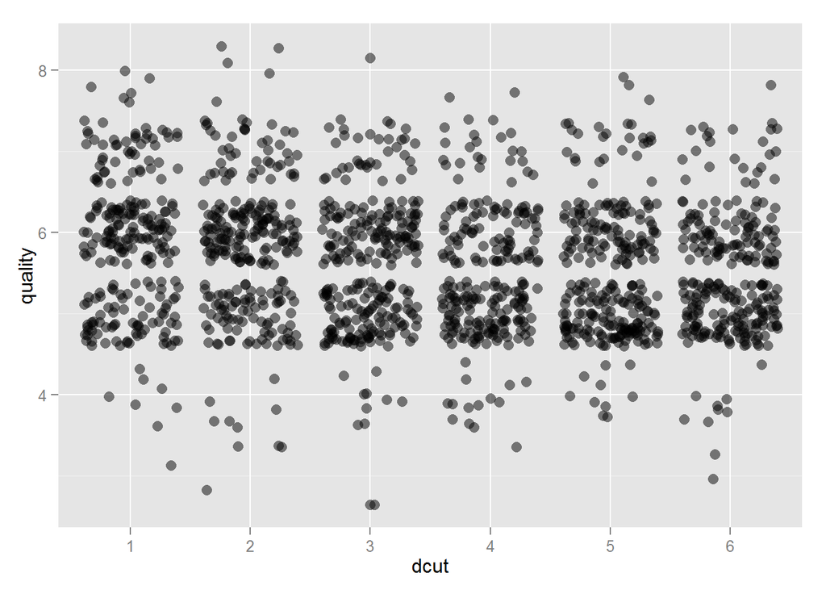

```r
ggplot(aes(x=dcut, y=quality), data=wqr) +
  geom_point(alpha = 1/2, position="jitter", size=3)
```

Plots do not reveal anything significant, although very colorful. Perhaps pH will reveal something.

```r
wqr$pHcut<- cut(wqr$pH,
                breaks = c(0, quantile(wqr$pH, 1/12),quantile(wqr$pH, 2/12),
                           quantile(wqr$pH, 3/12),quantile(wqr$pH, 4/12),
                           quantile(wqr$pH, 5/12),quantile(wqr$pH, 6/12),
                           quantile(wqr$pH, 7/12),quantile(wqr$pH, 8/12),
                           quantile(wqr$pH, 9/12),quantile(wqr$pH, 10/12),
                           quantile(wqr$pH, 11/12),quantile(wqr$pH, 12/12)))
levels(wqr$pHcut)
```

```
##  [1] "(0,3.1]"     "(3.1,3.16]"  "(3.16,3.21]" "(3.21,3.25]" "(3.25,3.28]"
##  [6] "(3.28,3.31]" "(3.31,3.34]" "(3.34,3.37]" "(3.37,3.4]"  "(3.4,3.45]"
## [11] "(3.45,3.53]" "(3.53,4.01]"
```

```r
levels(wqr$pHcut)<-c("1","2","3","4","5","6","6","5","4","3","2","1")

with(wqr, cor.test(quality, as.numeric(pHcut), method = 'pearson'))
```

```
##
##  Pearson's product-moment correlation
##
## data:  quality and as.numeric(pHcut)
## t = 0.422, df = 1597, p-value = 0.6731
## alternative hypothesis: true correlation is not equal to 0
## 95 percent confidence interval:
##  -0.03848218  0.05954919
## sample estimates:
##        cor
## 0.01055887
```

```r
with(wqr, table(factor(quality), pHcut))
```

```
##    pHcut
##       1   2   3   4   5   6
##   3   2   3   0   3   0   2
##   4  12   6   8   7   6  14
##   5 104 133 117 107  95 125
##   6  97  98 125 102  85 131
##   7  33  24  38  35  32  37
##   8   4   5   2   5   2   0
```

```r
with(subset(wqr, as.numeric(wqr$dcut)>=5), table(factor(quality), pHcut))
```

```
##    pHcut
##      1  2  3  4  5  6
##   3  1  0  0  0  0  1
##   4  1  3  3  3  2  6
##   5 30 50 60 48 37 53
##   6 23 24 37 27 35 50
##   7  6  5  9 11  5 11
##   8  0  3  0  0  1  0
```

Not looking good with pH, maybe a combination of pH and density will reveal an unexpected correlation.

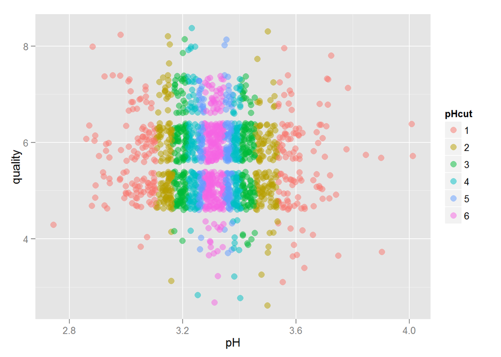

```r
ggplot(aes(x = pH, y = quality, color = pHcut), data = wqr) +
  geom_point(alpha = 1/2, position = "jitter", size = 3)
```

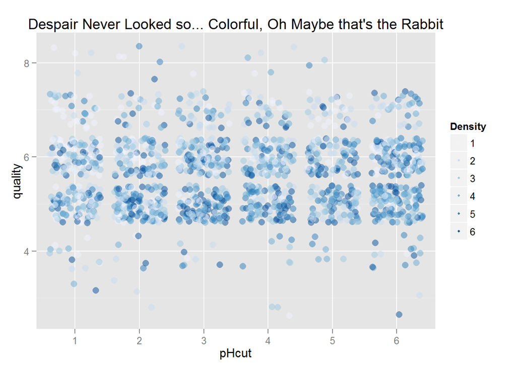

```r
ggplot(aes(x = pHcut, y = quality, color = dcut), data = wqr) +
  geom_point(alpha = 1/2, position = 'jitter', size = 3) +
  ggtitle("Despair Never Looked so... Colorful, Oh Maybe that's the Rabbit") +
  scale_color_brewer(type = 'seq', palette = 'Blues',
    guide = guide_legend(title = 'Density', reverse = F,
    override.aes = list(alpha = 1, size = 1)))
```

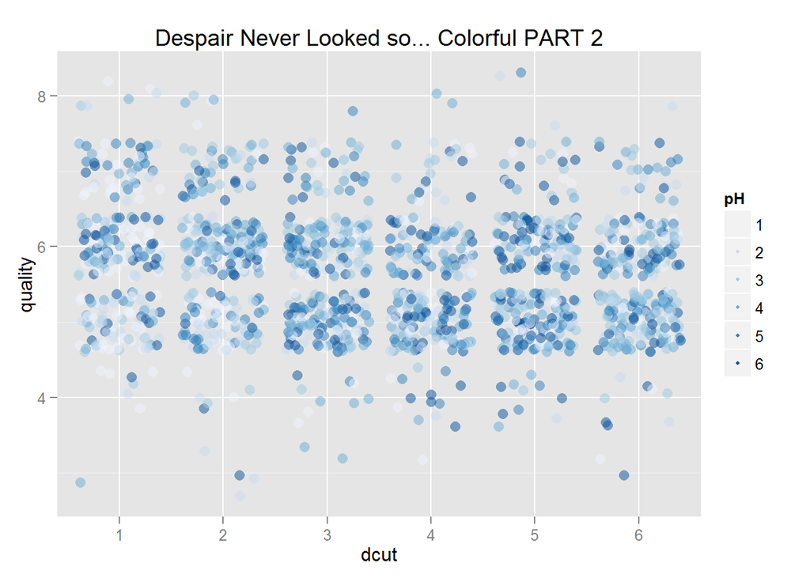

```r
ggplot(aes(color = pHcut, y = quality, x = dcut), data = wqr) +
  geom_point(alpha = 1/2, position = 'jitter', size = 3)+
  ggtitle("Despair Never Looked so... Colorful PART 2")+
  scale_color_brewer(type = 'seq', palette = 'Blues',
    guide = guide_legend(title = 'pH', reverse = F,
    override.aes = list(alpha = 1, size = 1)))
```

pH investigation dead-end, though I still haven’t given up that there might be something in the normally distributed data. Maybe Chlorides and residual sugar have some story to tell.

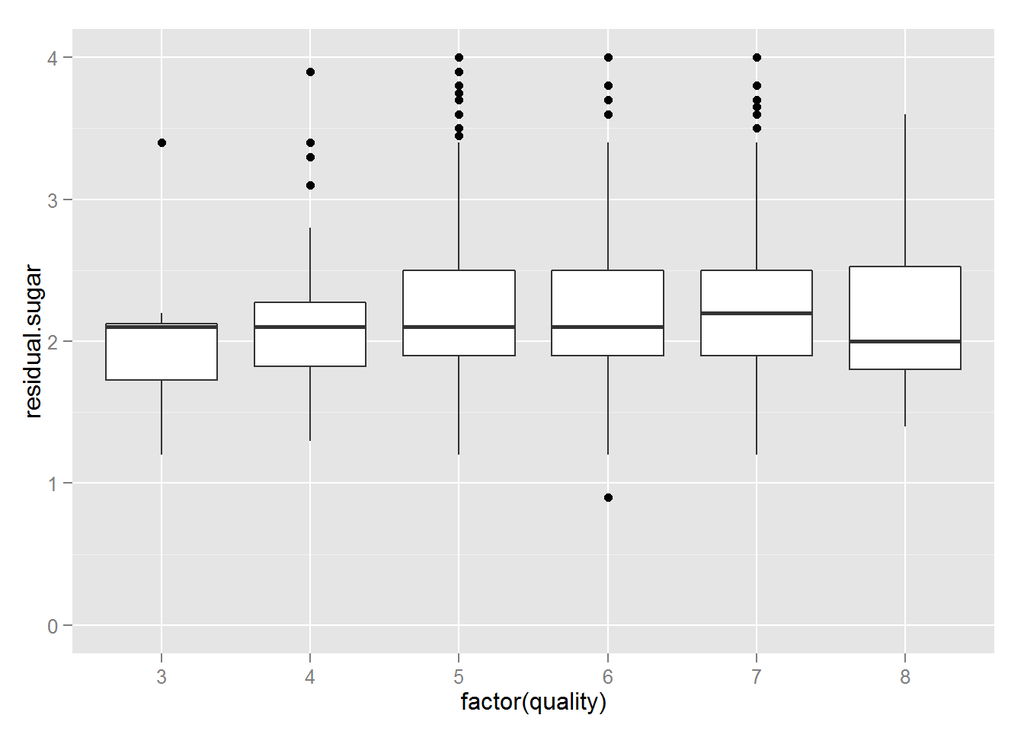

```r
ggplot(aes(x=factor(quality), y = residual.sugar), data = wqr) +
  geom_boxplot()+ylim(0,4)
```

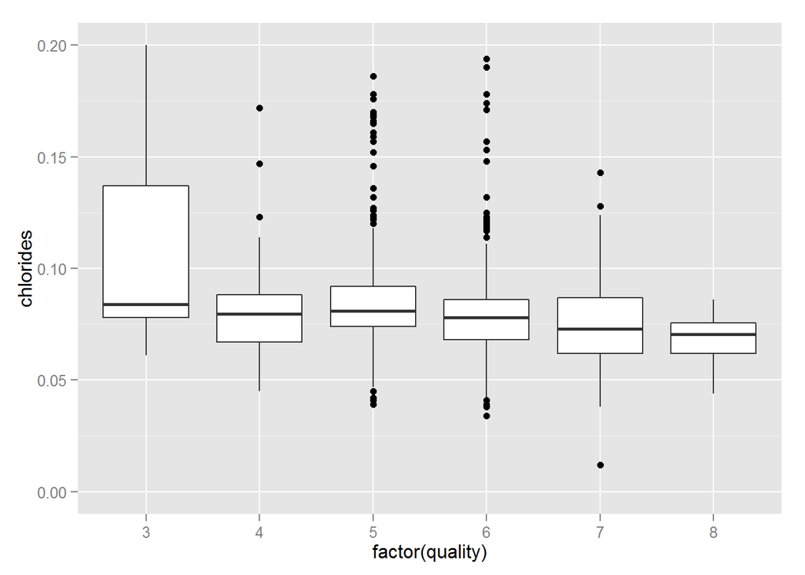

```r
ggplot(aes(x=factor(quality), y = chlorides), data = wqr) +
  geom_boxplot()+ylim(0,0.2)
```

```r
printVariance <- function(colname,data){
  for (i in 3:8){
    print(with(subset(get(data), get(data)$quality == i), var(get(colname))))
  }
}

printVariance("residual.sugar",'wqr')
```

```
## [1] 1.964472
## [1] 3.202083
## [1] 1.848927
## [1] 2.078141
## [1] 1.881038
## [1] 1.677124
```

```r
printVariance("chlorides",'wqr')
```

```
## [1] 0.004387833
## [1] 0.005805184
## [1] 0.002884486
## [1] 0.001565254
## [1] 0.0008676273
## [1] 0.0001363791
```

```r
printVariance("pH",'wqr')
```

```
## [1] 0.02075111
## [1] 0.03292075
## [1] 0.02268592
## [1] 0.02371449
## [1] 0.02253024
## [1] 0.04025654
```

```r
printVariance("density",'wqr')
```

```
## [1] 4.007382e-06
## [1] 2.481157e-06
## [1] 2.523346e-06
## [1] 4.000036e-06
## [1] 4.733842e-06
## [1] 5.656195e-06
```

```r
summary(wqr$chlorides)
```

```
##    Min. 1st Qu.  Median    Mean 3rd Qu.    Max.
## 0.01200 0.07000 0.07900 0.08747 0.09000 0.61100
```

Can people actually taste .1 g/liter of chloride/salt? This might be a futile exercise. Looked at variances of several variables to see if there is a trend of increasing or decreasing variance. This could indicate that the tails of the distribution might contain correlation to one particular quality level once again the ‘Too much and too little’ theory.

```r
wqr$chlcut<- cut(wqr$chlorides,
  breaks = c(0, quantile(wqr$chlorides, 1/12),quantile(wqr$chlorides, 2/12),
             quantile(wqr$chlorides, 3/12),quantile(wqr$chlorides, 4/12),
             quantile(wqr$chlorides, 5/12),quantile(wqr$chlorides, 6/12),
             quantile(wqr$chlorides, 7/12),quantile(wqr$chlorides, 8/12),
             quantile(wqr$chlorides, 9/12),quantile(wqr$chlorides, 10/12),
             quantile(wqr$chlorides, 11/12),quantile(wqr$chlorides, 12/12)))
levels(wqr$chlcut)
```

```
##  [1] "(0,0.059]"     "(0.059,0.066]" "(0.066,0.07]"  "(0.07,0.074]"
##  [5] "(0.074,0.076]" "(0.076,0.079]" "(0.079,0.082]" "(0.082,0.085]"
##  [9] "(0.085,0.09]"  "(0.09,0.097]"  "(0.097,0.114]" "(0.114,0.611]"
```

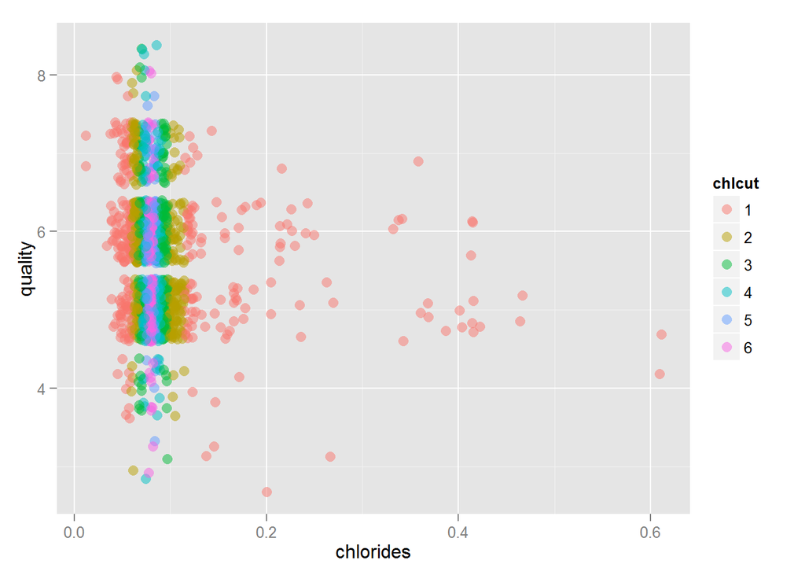

```r
levels(wqr$chlcut)<-c("1","2","3","4","5","6","6","5","4","3","2","1")


ggplot(aes(x=chlorides, y=quality, color=chlcut), data=wqr) +
  geom_point(alpha = 1/2, position="jitter", size=3)
```

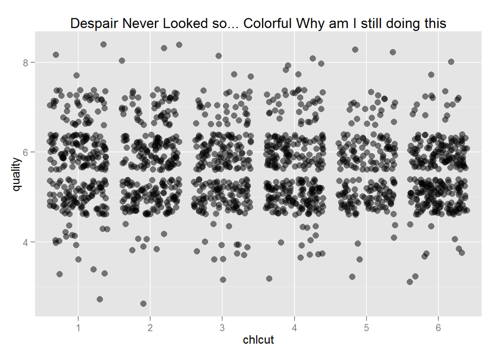

```r
ggplot(aes( y=quality, x=chlcut), data=wqr) +
  geom_point(alpha = 1/2, position='jitter', size=3)+
  ggtitle("Despair Never Looked so... Colorful Why am I still doing this")+
  scale_color_brewer(type = 'seq', palette = 'Blues',
    guide = guide_legend(title = 'pH', reverse = F,
    override.aes = list(alpha = 1, size = 1)))
```

```r
with(wqr, table(factor(quality), chlcut))
```

```
##    chlcut
##       1   2   3   4   5   6
##   3   4   1   1   1   1   2
##   4  12   7  12  11   4   7
##   5  98 114 101 132  93 143
##   6 112 104 102 111  84 125
##   7  45  50  34  35  21  14
##   8   3   3   3   5   2   2
```

A search on the internet revealed that most likely the % of salt contained in these wines are not at levels that are able to be tasted by most humans. And once again, the ‘folding’ of the distribution has not revealed any new correlations.

### 3. Further Exploration some Multivariate

**Alcohol**

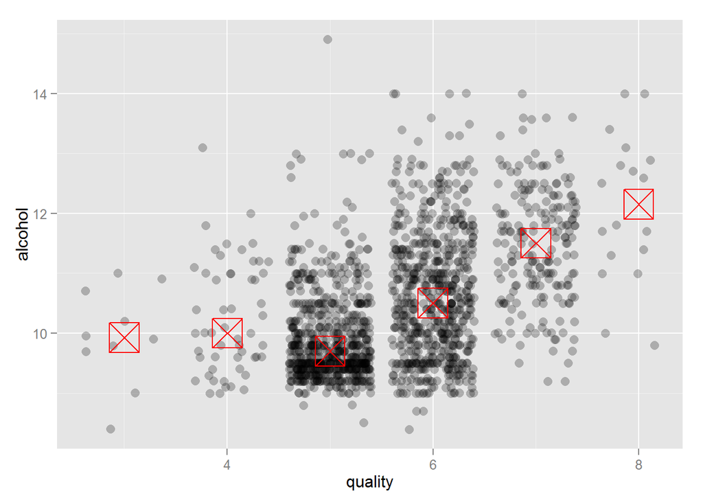

```r
#Visualization of the relationship between Alchohol content and Quality

ggplot(aes(x=quality, y=alcohol), data = wqr) +
  geom_point(alpha=1/4, position='jitter', size = 3) +
  stat_summary(fun.y = median, geom = 'point',
               shape = 7, size = 10, color = 'red')
```

Alcohol vs quality (a little backwards in the axis but it seems more natural to place quality on the x for visualization purposes). Added the median to see the the possible linear relationship with quality.

```r
wqr$qual.cut <- cut(wqr$quality, breaks = c(2,4,5,6,7,8))
levels(wqr$qual.cut)
```

```
## [1] "(2,4]" "(4,5]" "(5,6]" "(6,7]" "(7,8]"
```

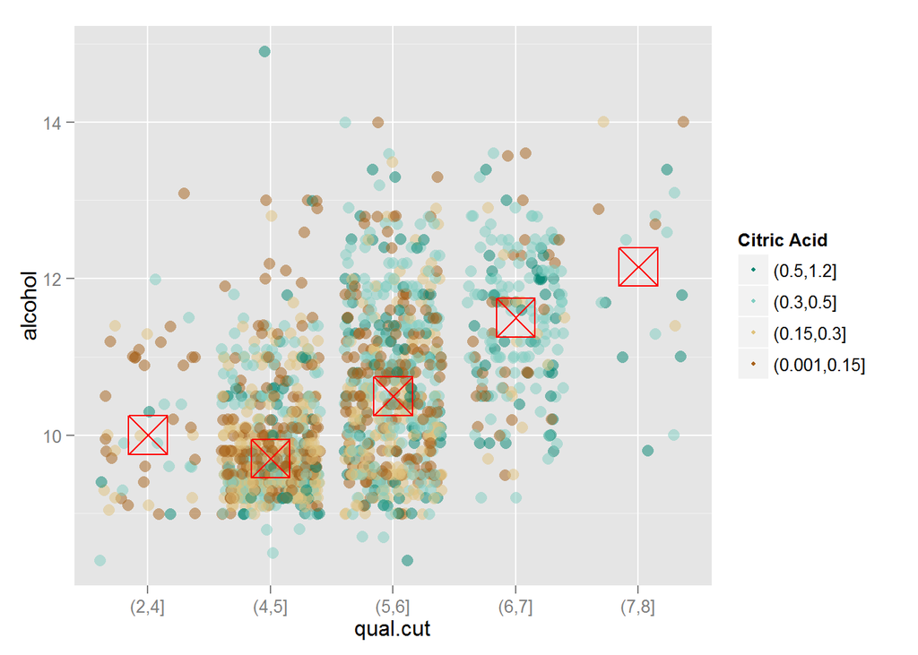

```r
ggplot(aes(x=qual.cut, y=alcohol, color = cAcid.cut), data = wqr) +
  scale_color_brewer(type = 'div',
    guide = guide_legend(title = 'Citric Acid', reverse = T,
    override.aes = list(alpha = 1, size = 1))) +
  geom_point(alpha=1/2, position='jitter', size = 3) +
  stat_summary(fun.y = median, geom = 'point',
               shape = 7, size = 10, color = 'red')
```

```r
with(wqr, cor.test(as.numeric(qual.cut), alcohol, method = 'pearson'))
```

```
##
##  Pearson's product-moment correlation
##
## data:  as.numeric(qual.cut) and alcohol
## t = 22.0304, df = 1597, p-value < 2.2e-16
## alternative hypothesis: true correlation is not equal to 0
## 95 percent confidence interval:
##  0.4442698 0.5195032
## sample estimates:
##       cor
## 0.4827767
```

Created a new categorical variable out of *‘quality’* called *‘qual.cut’* by merging the bottom 2 categories in *‘quality’*. Hope to make trends a bit clearer and provide a cleaner view of the bins.

**Volatile Acidity**

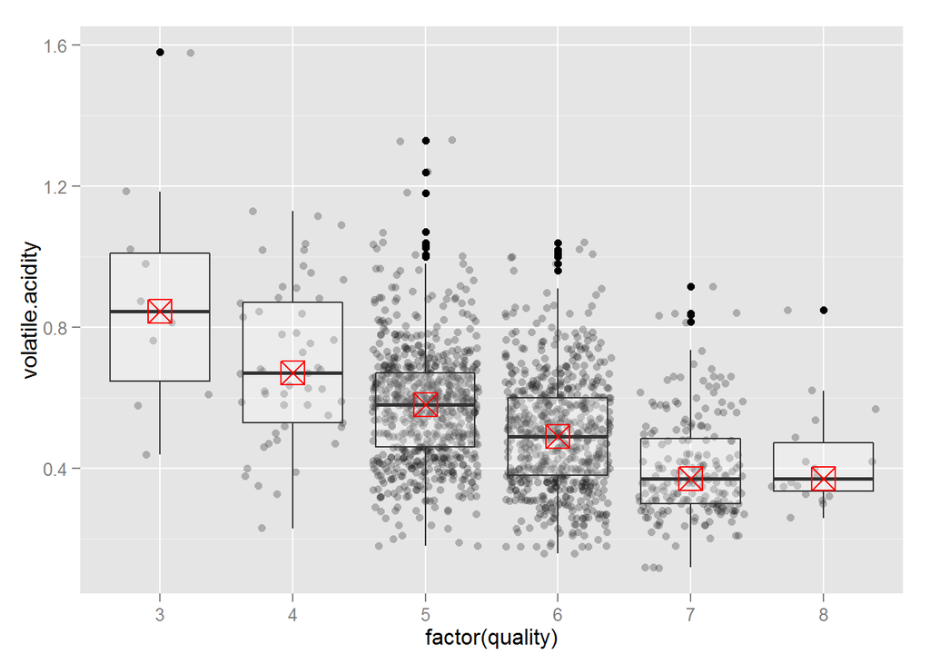

```r
#Better Visualize the relationship between Volatile Acidity and Quality
ggplot(aes(x=factor(quality), y=volatile.acidity), data = wqr) +
  geom_point(alpha=1/4, position='jitter', size = 2)+
  geom_boxplot(alpha = .25)+
  stat_summary(fun.y = median, geom = 'point',
               shape = 7, size = 6, color = 'red')
```

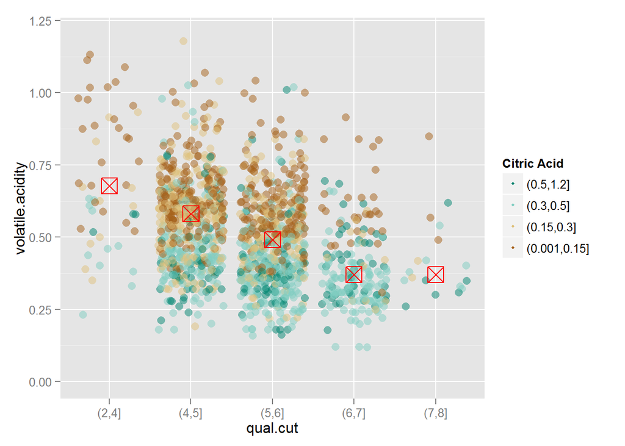

```r
#Facet on Citric Acid
ggplot(aes(x=qual.cut, y=volatile.acidity, color = cAcid.cut), data = wqr) +
  scale_color_brewer(type = 'div',
    guide = guide_legend(title = 'Citric Acid', reverse = T,
    override.aes = list(alpha = 1, size = 1))) +
  geom_point(alpha=1/2, position='jitter', size = 3) +
  stat_summary(fun.y = median, geom = 'point', shape = 7,
               size = 6, color = 'red') + ylim(0, 1.2)
```

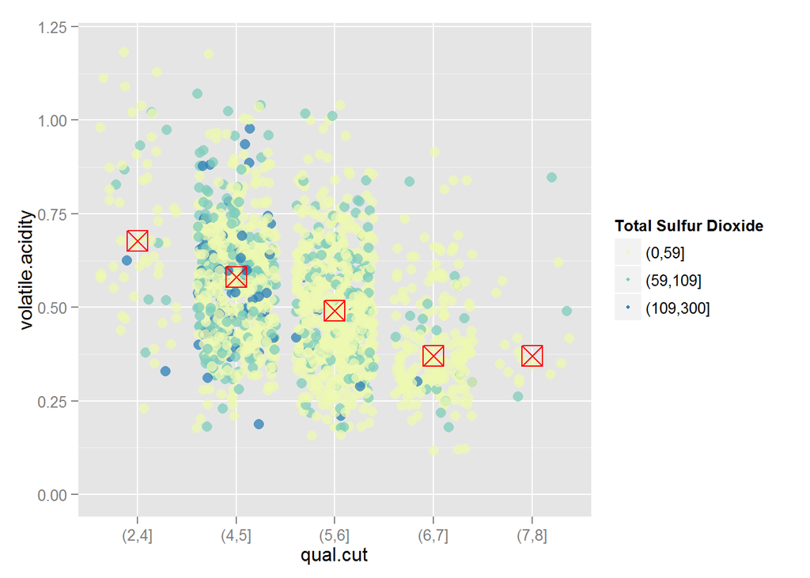

```r
#Volatile Acidity colored by Total Sulfure Dioxide categorical Variable
ggplot(aes(x=qual.cut, y=volatile.acidity, color = total.sulf.dioxide.cut),
       data = wqr) +
  scale_color_brewer(type = 'seq', palette = 'YlGnBu',
    guide = guide_legend(title = 'Total Sulfur Dioxide', reverse = F,
    override.aes = list(alpha = 1, size = 1))) +
  geom_point(alpha=.75, position='jitter', size = 3) +
  stat_summary(fun.y = median, geom = 'point',
               shape = 7, size = 6, color = 'red') + ylim(0, 1.2)
```

**Sulphates**

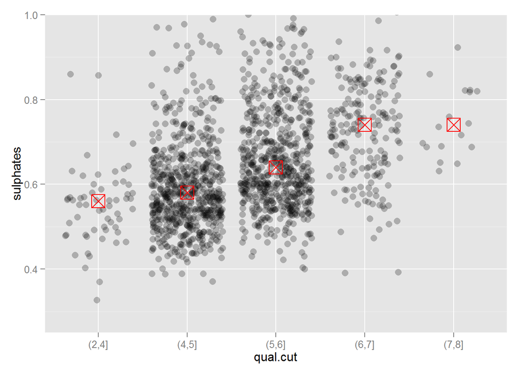

```r
ggplot(aes(x=qual.cut, y=sulphates), data = wqr) +
  geom_point(alpha=1/4, position='jitter', size = 3) +
  stat_summary(fun.y = median, geom = 'point', shape = 7,
               size = 6, color = 'red')+coord_cartesian(ylim=c(.25,1))
```

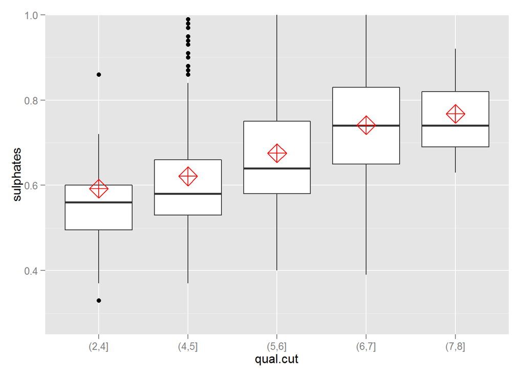

```r
ggplot(aes(x=qual.cut, y = sulphates), data =wqr) +
  geom_boxplot() + coord_cartesian(ylim=c(.25,1)) +
  stat_summary(fun.y = mean, geom = 'point', shape = 9, size = 6, color = 'red')
```

Sulphates seem to be linearly correlated with quality as shown by the ggpairs correlation matrix this is a good variable add to a model.

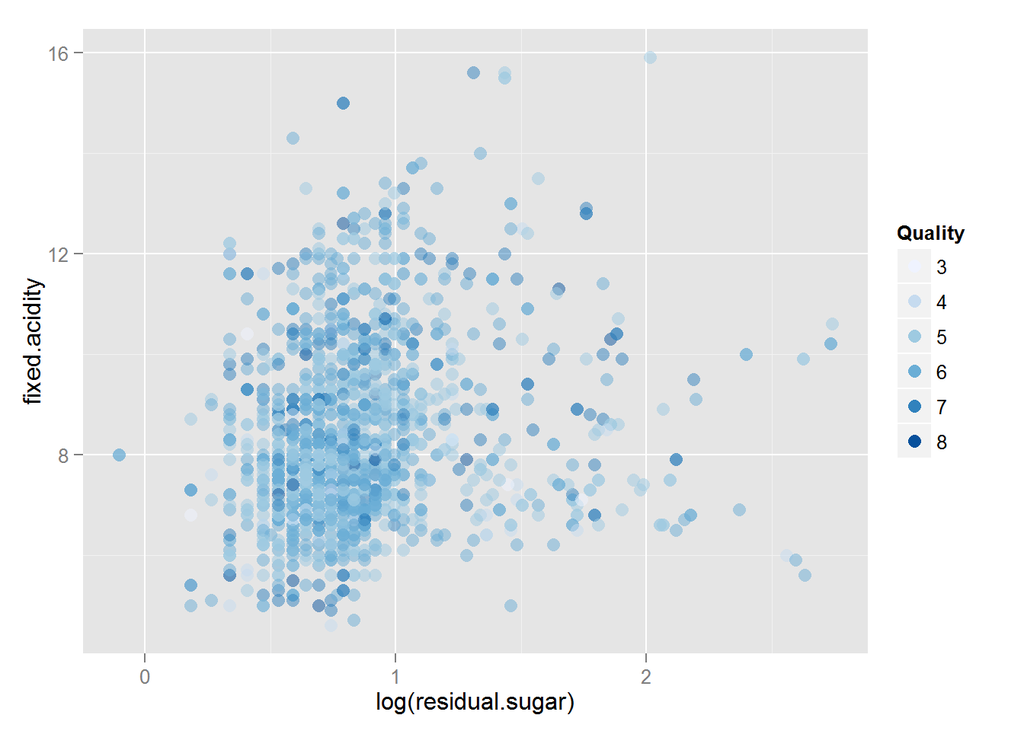

```r
#Fixed Acidity vs Sugar colored by quality
ggplot(aes(x=log(residual.sugar), y = fixed.acidity, color=factor(quality)),
       data = wqr)+ geom_point(size = 3, alpha = .5)+
  scale_color_brewer(type = 'seq', palette = 'Blues',
    guide = guide_legend(title = 'Quality', reverse = F,
    override.aes = list(alpha = 1, size = 3)))
```

Feeling somewhat unsatisfied with the current findings and the lack of elements to account for the variance in the quality ratings (although quality ratings are subjective and discrete), I started reading about how wine is rated. There are many subjective measures in rating wines, but the one that makes the most sense is Appearance (Visual), Aroma(smell), *Taste*, and Aftertaste (finish). Perhaps it’s best to see how good of a model we can obtain from the current inputs.

**Modeling the Data**

```r
m1 <- lm(I(quality) ~ alcohol, data = wqr)
m2 <- update(m1, ~ . + sulphates)
m3 <- update(m2, ~ . + volatile.acidity)
m4 <- update(m3, ~ . + cAcid.cut)
m5 <- update(m4, ~ . + total.sulf.dioxide.cut)
m6 <- update(m5, ~ . + chloride.cut)
m7 <- update(m6, ~ . + density.cut)
m8 <- update(m7, ~ . + pH)
m9 <- update(m8, ~ . + fixed.acidity)
m10 <- update(m9, ~ . + residual.sugar)
m11 <- update(m10, ~ . + free.sulfur.dioxide)

mtable(m1, m2, m3, m4, m5, m6, m7, m8,m9,m10,m11)
```

```
##
## Calls:
## m1: lm(formula = I(quality) ~ alcohol, data = wqr)
## m2: lm(formula = I(quality) ~ alcohol + sulphates, data = wqr)
## m3: lm(formula = I(quality) ~ alcohol + sulphates + volatile.acidity,
##     data = wqr)
## m4: lm(formula = I(quality) ~ alcohol + sulphates + volatile.acidity +
##     cAcid.cut, data = wqr)
## m5: lm(formula = I(quality) ~ alcohol + sulphates + volatile.acidity +
##     cAcid.cut + total.sulf.dioxide.cut, data = wqr)
## m6: lm(formula = I(quality) ~ alcohol + sulphates + volatile.acidity +
##     cAcid.cut + total.sulf.dioxide.cut + chloride.cut, data = wqr)
## m7: lm(formula = I(quality) ~ alcohol + sulphates + volatile.acidity +
##     cAcid.cut + total.sulf.dioxide.cut + chloride.cut + density.cut,
##     data = wqr)
## m8: lm(formula = I(quality) ~ alcohol + sulphates + volatile.acidity +
##     cAcid.cut + total.sulf.dioxide.cut + chloride.cut + density.cut +
##     pH, data = wqr)
## m9: lm(formula = I(quality) ~ alcohol + sulphates + volatile.acidity +
##     cAcid.cut + total.sulf.dioxide.cut + chloride.cut + density.cut +
##     pH + fixed.acidity, data = wqr)
## m10: lm(formula = I(quality) ~ alcohol + sulphates + volatile.acidity +
##     cAcid.cut + total.sulf.dioxide.cut + chloride.cut + density.cut +
##     pH + fixed.acidity + residual.sugar, data = wqr)
## m11: lm(formula = I(quality) ~ alcohol + sulphates + volatile.acidity +
##     cAcid.cut + total.sulf.dioxide.cut + chloride.cut + density.cut +
##     pH + fixed.acidity + residual.sugar + free.sulfur.dioxide,
##     data = wqr)
##
## =======================================================================================================================================================
##                                              m1        m2        m3        m4        m5        m6        m7        m8        m9        m10       m11
## -------------------------------------------------------------------------------------------------------------------------------------------------------
## (Intercept)                                1.875***  1.375***  2.611***  2.556***  2.665***  2.697***  2.750***  4.080***  3.732***  3.646***  3.704***
##                                           (0.175)   (0.177)   (0.196)   (0.218)   (0.217)   (0.230)   (0.247)   (0.492)   (0.673)   (0.676)   (0.676)
## alcohol                                    0.361***  0.346***  0.309***  0.317***  0.301***  0.295***  0.290***  0.304***  0.300***  0.292***  0.295***
##                                           (0.017)   (0.016)   (0.016)   (0.017)   (0.017)   (0.018)   (0.020)   (0.021)   (0.021)   (0.022)   (0.022)
## sulphates                                            0.994***  0.679***  0.630***  0.670***  0.705***  0.712***  0.686***  0.694***  0.710***  0.693***
##                                                     (0.102)   (0.101)   (0.105)   (0.104)   (0.106)   (0.106)   (0.106)   (0.107)   (0.107)   (0.108)
## volatile.acidity                                              -1.221*** -1.170*** -1.067*** -1.024*** -1.012*** -1.026*** -1.031*** -1.035*** -1.009***
##                                                               (0.097)   (0.123)   (0.123)   (0.125)   (0.126)   (0.126)   (0.126)   (0.126)   (0.127)
```

[output cut: 25 more lines]

```
##                                                                                                                                     (0.013)   (0.013)
## free.sulfur.dioxide                                                                                                                            0.004
##                                                                                                                                               (0.002)
## -------------------------------------------------------------------------------------------------------------------------------------------------------
## R-squared                                     0.227     0.270     0.336     0.335     0.349     0.351     0.352     0.356     0.356     0.357     0.359
## adj. R-squared                                0.226     0.269     0.335     0.332     0.345     0.347     0.346     0.350     0.350     0.350     0.351
## sigma                                         0.710     0.690     0.659     0.658     0.651     0.650     0.651     0.649     0.649     0.649     0.648
## F                                           468.267   294.988   268.912   122.348    97.582    71.693    60.624    57.329    53.529    50.371    47.674
## p                                             0.000     0.000     0.000     0.000     0.000     0.000     0.000     0.000     0.000     0.000     0.000
## Log-likelihood                            -1721.057 -1675.142 -1599.384 -1463.199 -1447.445 -1444.307 -1444.121 -1439.214 -1438.925 -1437.771 -1436.117
## Deviance                                    805.870   760.894   692.105   631.385   617.968   615.331   615.174   611.073   610.832   609.872   608.498
## AIC                                        3448.114  3358.284  3208.768  2942.398  2914.889  2914.614  2918.241  2910.428  2911.850  2911.541  2910.234
## BIC                                        3464.245  3379.793  3235.654  2984.726  2967.799  2983.397  2997.606  2995.084  3001.797  3006.779  3010.762
## N                                          1599      1599      1599      1467      1467      1467      1467      1467      1467      1467      1467
## =======================================================================================================================================================
```

I decided to run a linear regression test to see how much of the variance in quality I can capture. The result is about 36% of the variance with all independent variables modeled. The same model was run with the original non-categorical variables, the resulting model was about 1-2% worse. There are several considerations:

1. *‘quality’* is essentially a categorical variable and should not be treated as a continuous one even though it looks like one.
2. A linear model might not be the best model, perhaps a non-linear approach could yield better results
3. Perhaps the data does not capture enough of the variance as there are other subjective measures that *wine experts* take into account when rating wines such has Appearance and Aroma

```r
#Take into account that quality is a categorical variable and perform a
#generalized linear regression with probit
m1 <- glm(factor(quality) ~ alcohol, family = binomial(link = "probit"),
          data = wqr)
m2 <- update(m1, ~ . + sulphates)
m3 <- update(m2, ~ . + volatile.acidity)
m4 <- update(m3, ~ . + cAcid.cut)
m5 <- update(m4, ~ . + total.sulf.dioxide.cut)
m6 <- update(m5, ~ . + chloride.cut)
m7 <- update(m6, ~ . + density.cut)
m8 <- update(m7, ~ . + pH)
m9 <- update(m8, ~ . + fixed.acidity)
m10 <- update(m9, ~ . + residual.sugar)
m11 <- update(m10, ~ . + free.sulfur.dioxide)
mtable(m1, m2, m3, m4, m5, m6, m7, m8,m9,m10,m11)
```

```
##
## Calls:
## m1: glm(formula = factor(quality) ~ alcohol, family = binomial(link = "probit"),
##     data = wqr)
## m2: glm(formula = factor(quality) ~ alcohol + sulphates, family = binomial(link = "probit"),
##     data = wqr)
## m3: glm(formula = factor(quality) ~ alcohol + sulphates + volatile.acidity,
##     family = binomial(link = "probit"), data = wqr)
## m4: glm(formula = factor(quality) ~ alcohol + sulphates + volatile.acidity +
##     cAcid.cut, family = binomial(link = "probit"), data = wqr)
## m5: glm(formula = factor(quality) ~ alcohol + sulphates + volatile.acidity +
##     cAcid.cut + total.sulf.dioxide.cut, family = binomial(link = "probit"),
##     data = wqr)
## m6: glm(formula = factor(quality) ~ alcohol + sulphates + volatile.acidity +
##     cAcid.cut + total.sulf.dioxide.cut + chloride.cut, family = binomial(link = "probit"),
##     data = wqr)
## m7: glm(formula = factor(quality) ~ alcohol + sulphates + volatile.acidity +
##     cAcid.cut + total.sulf.dioxide.cut + chloride.cut + density.cut,
##     family = binomial(link = "probit"), data = wqr)
## m8: glm(formula = factor(quality) ~ alcohol + sulphates + volatile.acidity +
##     cAcid.cut + total.sulf.dioxide.cut + chloride.cut + density.cut +
##     pH, family = binomial(link = "probit"), data = wqr)
## m9: glm(formula = factor(quality) ~ alcohol + sulphates + volatile.acidity +
##     cAcid.cut + total.sulf.dioxide.cut + chloride.cut + density.cut +
##     pH + fixed.acidity, family = binomial(link = "probit"), data = wqr)
## m10: glm(formula = factor(quality) ~ alcohol + sulphates + volatile.acidity +
##     cAcid.cut + total.sulf.dioxide.cut + chloride.cut + density.cut +
##     pH + fixed.acidity + residual.sugar, family = binomial(link = "probit"),
##     data = wqr)
## m11: glm(formula = factor(quality) ~ alcohol + sulphates + volatile.acidity +
##     cAcid.cut + total.sulf.dioxide.cut + chloride.cut + density.cut +
##     pH + fixed.acidity + residual.sugar + free.sulfur.dioxide,
##     family = binomial(link = "probit"), data = wqr)
##
## ========================================================================================================================================================================================
##                                                m1           m2           m3           m4           m5           m6           m7           m8           m9          m10          m11
## ----------------------------------------------------------------------------------------------------------------------------------------------------------------------------------------
## (Intercept)                                  0.597       -0.248       1.362          0.496        0.823        1.548       1.621       10.570        14.461       14.996      14.374
##                                             (1.339)      (1.447)     (2.037)        (2.491)      (2.700)      (2.865)     (3.222)      (6.242)       (8.612)      (8.747)     (8.777)
## alcohol                                      0.186        0.164       0.322          0.364        0.514*       0.524       0.606*       0.711*        0.779*       0.824*      0.885*
```

[output cut: 32 more lines]

```
##                                                                                                                                                                               (0.028)
## ----------------------------------------------------------------------------------------------------------------------------------------------------------------------------------------
## Aldrich-Nelson R-sq.                           0.001        0.004        0.018        0.014        0.021        0.022        0.024        0.026        0.027        0.027        0.027
## McFadden R-sq.                                 0.019        0.047        0.246        0.231        0.348        0.364        0.413        0.448        0.454        0.456        0.463
## Cox-Snell R-sq.                                0.001        0.004        0.018        0.014        0.021        0.022        0.025        0.027        0.027        0.027        0.028
## Nagelkerke R-sq.                               0.020        0.049        0.253        0.236        0.355        0.371        0.420        0.455        0.461        0.463        0.471
## phi                                            1.000        1.000        1.000        1.000        1.000        1.000        1.000        1.000        1.000        1.000        1.000
## Likelihood-ratio                               2.290        5.681       29.826       20.499       30.874       32.296       36.644       39.768       40.294       40.471       41.134
## p                                              0.130        0.058        0.000        0.002        0.000        0.001        0.000        0.000        0.000        0.001        0.001
## Log-likelihood                               -59.569      -57.873      -45.801      -34.149      -28.962      -28.251      -26.077      -24.515      -24.252      -24.163      -23.832
## Deviance                                     119.139      115.747       91.602       68.298       57.924       56.502       52.153       49.030       48.503       48.326       47.663
## AIC                                          123.139      121.747       99.602       82.298       75.924       80.502       80.153       79.030       80.503       82.326       83.663
## BIC                                          133.893      137.878      121.111      119.335      123.542      143.994      154.227      158.395      165.159      172.273      178.901
## N                                           1599         1599         1599         1467         1467         1467         1467         1467         1467         1467         1467
## ========================================================================================================================================================================================
```

**Sulfur Dioxide and Sulphate Exploration**

```
## geom_smooth: method="auto" and size of largest group is >=1000, so using gam with formula: y ~ s(x, bs = "cs"). Use 'method = x' to change the smoothing method.
```

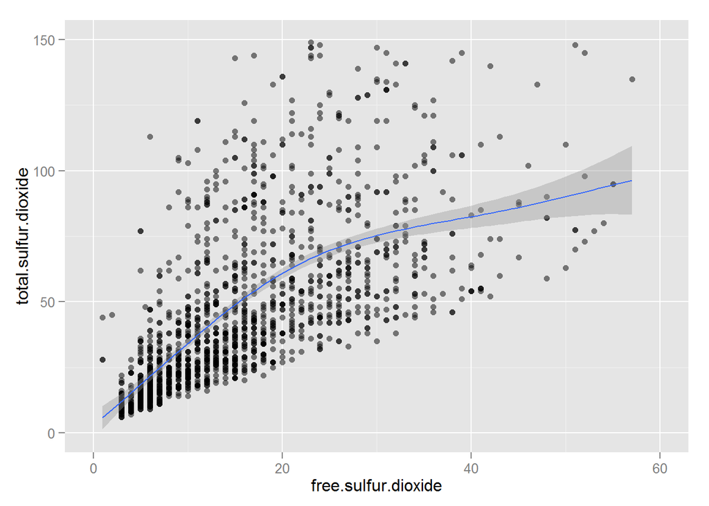

```r
ggplot(aes(x = free.sulfur.dioxide, y=total.sulfur.dioxide), data = wqr) +
  geom_point(alpha=1/2)+geom_smooth()+ylim(0,150)+xlim(0,60)
```

```
## geom_smooth: method="auto" and size of largest group is >=1000, so using gam with formula: y ~ s(x, bs = "cs"). Use 'method = x' to change the smoothing method.
```

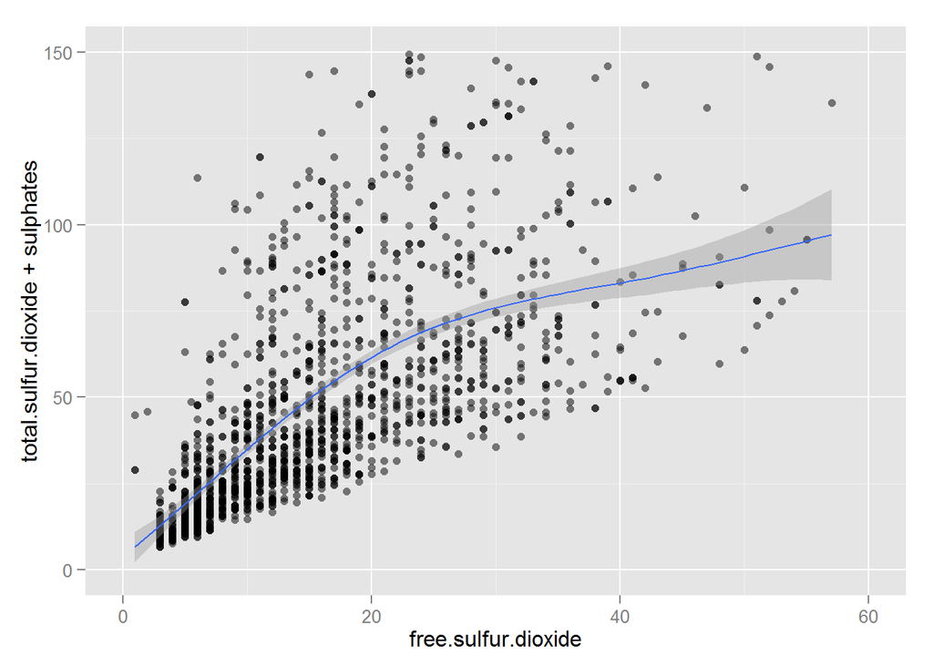

```r
ggplot(aes(x = free.sulfur.dioxide, y=total.sulfur.dioxide+sulphates),
       data = wqr) + geom_point(alpha=1/2)+geom_smooth()+ylim(0,150)+xlim(0,60)
```

```r
#grid.arrange(sul1,sul2,ncol=2)

corFT <-with(wqr, cor.test(free.sulfur.dioxide,total.sulfur.dioxide))
corFS <- with(wqr, cor.test(free.sulfur.dioxide,sulphates))
corFTS <- with(wqr, cor.test(free.sulfur.dioxide,total.sulfur.dioxide +
                               sulphates))
corFT$estimate
```

```
##       cor
## 0.6676665
```

```r
corFS$estimate
```

```
##        cor
## 0.05165757
```

```r
corFTS$estimate
```

```
##      cor
## 0.667776
```

```r
modFTS <- lm(free.sulfur.dioxide ~
               total.sulfur.dioxide+sulphates+residual.sugar, data = wqr)
mtable(modFTS)
```

```
##
## Calls:
## modFTS: lm(formula = free.sulfur.dioxide ~ total.sulfur.dioxide + sulphates +
##     residual.sugar, data = wqr)
##
## ===============================
## (Intercept)            4.230***
##                       (0.871)
## total.sulfur.dioxide   0.209***
##                       (0.006)
## sulphates              1.432
##                       (1.148)
## residual.sugar         0.399**
##                       (0.141)
## -------------------------------
## R-squared                 0.449
## adj. R-squared            0.448
## sigma                     7.771
## F                       433.388
## p                         0.000
## Log-likelihood        -5545.516
## Deviance              96325.376
## AIC                   11101.032
## BIC                   11127.918
## N                      1599
## ===============================
```

```r
modFTS$coefficients
```

```
##          (Intercept) total.sulfur.dioxide            sulphates
##            4.2303610            0.2085175            1.4315258
##       residual.sugar
##            0.3990285
```

```r
wqr$sulfcomb <- 0.2119922*wqr$total.sulfur.dioxide +
  1.4209109*wqr$sulphates+5.0889418
corFTSmod<- with(wqr, cor.test(free.sulfur.dioxide,sulfcomb))
corFTSmod
```

```
##
##  Pearson's product-moment correlation
##
## data:  free.sulfur.dioxide and sulfcomb
## t = 35.8786, df = 1597, p-value < 2.2e-16
## alternative hypothesis: true correlation is not equal to 0
## 95 percent confidence interval:
##  0.6400010 0.6943446
## sample estimates:
##       cor
## 0.6680626
```

Surprisingly, linear combination between *‘sulphates’* and *‘total.sulfur.dioxide’* did not improve correlation with *‘free.sulfur.dioxide’*. Another dead-end where hypothesis and testing yielded a negative result. Ready to move on at this point.